# Practica Final

### Modelos y Aprendizaje estadístico con R.

#### Román López Seoane.

```r
#detach(datos_bancarios)
rm(list=ls())
```

##### Realizamos la carga del dataset y realizamos algunas inspecciones iniciales de los datos.

```r
datos_bancarios <- read.csv(file="datos/datos_bancarios.csv", header=FALSE, sep=";")
colnames(datos_bancarios)[16] <- "Aprobado"
head(datos_bancarios)
```

|  | V1 | V2 | V3 | V4 | V5 | V6 | V7 | V8 | V9 | V10 | V11 | V12 | V13 | V14 | V15 | Aprobado |
| --- | --- | --- | --- | --- | --- | --- | --- | --- | --- | --- | --- | --- | --- | --- | --- | --- |
| 1 | b | 30.83 | 0.000 | u | g | w | v | 1.25 | t | t | 1 | f | g | 202 | 0 | + |
| 2 | a | 58.67 | 4.460 | u | g | q | h | 3.04 | t | t | 6 | f | g | 43 | 560 | + |
| 3 | a | 24.50 | 0.500 | u | g | q | h | 1.50 | t | f | 0 | f | g | 280 | 824 | + |
| 4 | b | 27.83 | 1.540 | u | g | w | v | 3.75 | t | t | 5 | t | g | 100 | 3 | + |
| 5 | b | 20.17 | 5.625 | u | g | w | v | 1.71 | t | f | 0 | f | s | 120 | 0 | + |
| 6 | b | 32.08 | 4.000 | u | g | m | v | 2.50 | t | f | 0 | t | g | 360 | 0 | + |

```r
str(datos_bancarios)
```

```
'data.frame':   690 obs. of  16 variables:
 $ V1      : Factor w/ 3 levels "?","a","b": 3 2 2 3 3 3 3 2 3 3 ...
 $ V2      : Factor w/ 350 levels "?","13.75","15.17",..: 158 330 91 127 45 170 181 76 312 257 ...
 $ V3      : num  0 4.46 0.5 1.54 5.62 ...
 $ V4      : Factor w/ 4 levels "?","l","u","y": 3 3 3 3 3 3 3 3 4 4 ...
 $ V5      : Factor w/ 4 levels "?","g","gg","p": 2 2 2 2 2 2 2 2 4 4 ...
 $ V6      : Factor w/ 15 levels "?","aa","c","cc",..: 14 12 12 14 14 11 13 4 10 14 ...
 $ V7      : Factor w/ 10 levels "?","bb","dd",..: 9 5 5 9 9 9 5 9 5 9 ...
 $ V8      : num  1.25 3.04 1.5 3.75 1.71 ...
 $ V9      : Factor w/ 2 levels "f","t": 2 2 2 2 2 2 2 2 2 2 ...
 $ V10     : Factor w/ 2 levels "f","t": 2 2 1 2 1 1 1 1 1 1 ...
 $ V11     : int  1 6 0 5 0 0 0 0 0 0 ...
 $ V12     : Factor w/ 2 levels "f","t": 1 1 1 2 1 2 2 1 1 2 ...
 $ V13     : Factor w/ 3 levels "g","p","s": 1 1 1 1 3 1 1 1 1 1 ...
 $ V14     : Factor w/ 171 levels "?","0","100",..: 44 120 76 3 10 98 27 161 36 142 ...
 $ V15     : int  0 560 824 3 0 0 31285 1349 314 1442 ...
 $ Aprobado: Factor w/ 2 levels "-","+": 2 2 2 2 2 2 2 2 2 2 ...
```

Comprobamos que existen valores nulos en algunos casos, pero no están codificados como null. Lo modificamos para simplificar su gestión posteriormente.

```r
datos_bancarios[datos_bancarios=="?"]<-NA
sapply(datos_bancarios, function(x) sum(is.na(x)))
```

```
      V1       V2       V3       V4       V5       V6       V7       V8       V9      V10      V11      V12      V13      V14      V15 Aprobado
      12       12        0        6        6        9        9        0        0        0        0        0        0       13        0        0
```

Atendiendoa la información proporcionada en el ejercicio, vamos a realizar algunos cambios en los tipos de datos del data.frame:

```r
datos_bancarios[,2] <- sapply(datos_bancarios[,2], as.double)
datos_bancarios[,14] <- sapply(datos_bancarios[,14], as.integer)
head(datos_bancarios)
```

|  | V1 | V2 | V3 | V4 | V5 | V6 | V7 | V8 | V9 | V10 | V11 | V12 | V13 | V14 | V15 | Aprobado |
| --- | --- | --- | --- | --- | --- | --- | --- | --- | --- | --- | --- | --- | --- | --- | --- | --- |
| 1 | b | 158 | 0.000 | u | g | w | v | 1.25 | t | t | 1 | f | g | 44 | 0 | + |
| 2 | a | 330 | 4.460 | u | g | q | h | 3.04 | t | t | 6 | f | g | 120 | 560 | + |
| 3 | a | 91 | 0.500 | u | g | q | h | 1.50 | t | f | 0 | f | g | 76 | 824 | + |
| 4 | b | 127 | 1.540 | u | g | w | v | 3.75 | t | t | 5 | t | g | 3 | 3 | + |
| 5 | b | 45 | 5.625 | u | g | w | v | 1.71 | t | f | 0 | f | s | 10 | 0 | + |
| 6 | b | 170 | 4.000 | u | g | m | v | 2.50 | t | f | 0 | t | g | 98 | 0 | + |

## Apartado 1

##### Realiza una inspección por variables de la distribución de aprobación de crédito en función de cada atributo visualmente. Realiza las observaciones pertinentes. ¿ Qué variables son mejores para separar los datos?

En primer lugar realizamos una inspección de las variables cualitativas

```
attributes are not identical across measure variables;
they will be dropped
```

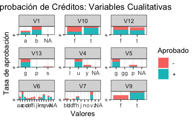

```r
#install.packages("gtools")
library(ggplot2)
library(tidyr)
library(dplyr)
#Utilizamos gather para preparar los datos y seleccionamos solo las variables cualitativas:
select(datos_bancarios,V1,V4,V5,V6,V7,V9,V10,V12,V13,Aprobado) %>% gather(-Aprobado, key = "var", value = "value")  %>%
  ggplot(aes(x=value, y=Aprobado, fill=Aprobado)) +
  geom_bar(stat="identity")+theme_minimal() +
  facet_wrap(~var, scales = "free") +
  ggtitle("Aprobación de Créditos: Variables Cualitativas") +
  xlab("Valores") +
  ylab("Tasa de aprobación") +
  theme_bw() +
  theme(plot.title = element_text(hjust = 0.5))
```

A continuación procedemos a examinar las variables cuantitativas.

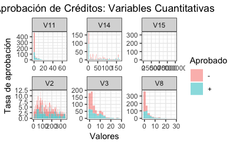

```r
#Variables continuas: V2, V3, V8, V11, V14 y V15
select(datos_bancarios,V2,V3,V8,V11,V14,V15,Aprobado) %>% gather(-Aprobado, key = "var", value = "value")  %>%
  ggplot(aes(x=value, fill=Aprobado)) +
  geom_histogram(binwidth=2, alpha=.5,position="stack") +theme_minimal() +
  facet_wrap(~var, scales = "free") +
  ggtitle("Aprobación de Créditos: Variables Cuantitativas") +
  xlab("Valores") +
  ylab("Tasa de aprobación") +
  theme_bw() +
  theme(plot.title = element_text(hjust = 0.5))
```

Para la variable V15 pintamos una función de densidad. Vemos que valores cercanos a 0 influyen en que no se apruebe el crédito, pero luego parece comportarse de forma muy estable para ambos valores.

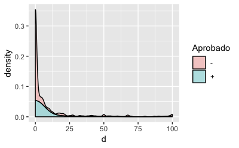

```r
d<-datos_bancarios$V15
ggplot(datos_bancarios, aes(x=d, fill=Aprobado)) + geom_density(alpha=.3,position="stack") +
  xlim(0, 100)
```

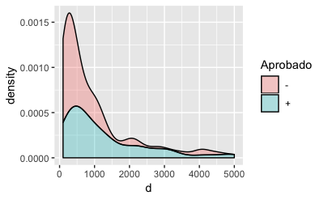

```r
ggplot(datos_bancarios, aes(x=d, fill=Aprobado)) + geom_density(alpha=.3,position="stack") +
  xlim(100, 5000)
```

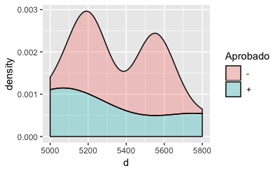

```r
ggplot(datos_bancarios, aes(x=d, fill=Aprobado)) + geom_density(alpha=.3,position="stack") +
  xlim(5000, 5800)
```

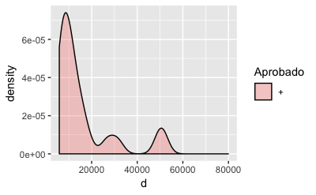

```r
ggplot(datos_bancarios, aes(x=d, fill=Aprobado)) + geom_density(alpha=.3,position="stack") +
  xlim(5800, 80000)
```

De forma complementaria vamos a hacer un Test Chi-cuadrado con las variables cualitativas. Así mismo vamos a ver la tabla de contingencia para alguna de las variables.

```r
#install.packages("gmodels")
library(gmodels)
tabla <- CrossTable (datos_bancarios$V9, datos_bancarios$Aprobado, prop.chisq = FALSE)
```

```
   Cell Contents
|-------------------------|
|                       N |
|           N / Row Total |
|           N / Col Total |
|         N / Table Total |
|-------------------------|


Total Observations in Table:  690


                   | datos_bancarios$Aprobado
datos_bancarios$V9 |         - |         + | Row Total |
-------------------|-----------|-----------|-----------|
                 f |       306 |        23 |       329 |
                   |     0.930 |     0.070 |     0.477 |
                   |     0.799 |     0.075 |           |
                   |     0.443 |     0.033 |           |
-------------------|-----------|-----------|-----------|
                 t |        77 |       284 |       361 |
                   |     0.213 |     0.787 |     0.523 |
                   |     0.201 |     0.925 |           |
                   |     0.112 |     0.412 |           |
-------------------|-----------|-----------|-----------|
      Column Total |       383 |       307 |       690 |
                   |     0.555 |     0.445 |           |
-------------------|-----------|-----------|-----------|
```

```r
tabla
```

```
$t
   y
x     -   +
  f 306  23
  t  77 284

$prop.row
   y
x            -          +
  f 0.93009119 0.06990881
  t 0.21329640 0.78670360

$prop.col
   y
x            -          +
  f 0.79895561 0.07491857
  t 0.20104439 0.92508143

$prop.tbl
   y
x            -          +
  f 0.44347826 0.03333333
  t 0.11159420 0.41159420
```

```r
tabla_chi <- CrossTable (datos_bancarios$V9, datos_bancarios$Aprobado, chisq=TRUE, prop.chisq = TRUE)
```

```
   Cell Contents
|-------------------------|
|                       N |
| Chi-square contribution |
|           N / Row Total |
|           N / Col Total |
|         N / Table Total |
|-------------------------|


Total Observations in Table:  690


                   | datos_bancarios$Aprobado
datos_bancarios$V9 |         - |         + | Row Total |
-------------------|-----------|-----------|-----------|
                 f |       306 |        23 |       329 |
                   |    83.359 |   103.995 |           |
                   |     0.930 |     0.070 |     0.477 |
                   |     0.799 |     0.075 |           |
                   |     0.443 |     0.033 |           |
-------------------|-----------|-----------|-----------|
                 t |        77 |       284 |       361 |
                   |    75.970 |    94.777 |           |
                   |     0.213 |     0.787 |     0.523 |
                   |     0.201 |     0.925 |           |
                   |     0.112 |     0.412 |           |
-------------------|-----------|-----------|-----------|
      Column Total |       383 |       307 |       690 |
                   |     0.555 |     0.445 |           |
-------------------|-----------|-----------|-----------|


Statistics for All Table Factors


Pearson's Chi-squared test
------------------------------------------------------------
Chi^2 =  358.1003     d.f. =  1     p =  7.29853e-80

Pearson's Chi-squared test with Yates' continuity correction
------------------------------------------------------------
Chi^2 =  355.2038     d.f. =  1     p =  3.11859e-79
```

```r
tabla_chi$chisq
```

```
    Pearson's Chi-squared test

data:  t
X-squared = 358.1, df = 1, p-value < 2.2e-16
```

Para las cuantitativas vamos a pintar la matriz de correlación.

```r
res <- cor(data.matrix(na.omit(select(datos_bancarios,V2,V3,V8,V11,V14,V15,Aprobado))))
res[7,]
```

```
        V2         V3         V8        V11        V14        V15   Aprobado
0.16358905 0.21332815 0.33519906 0.40728967 0.06809363 0.17288419 1.00000000
```

#### Conclusiones

> La variable cualitativa V9 es buena separando los datos en Créditos Aprobados o Rechazados. De este modo cuando dicha variable toma el valor “f” prácticamente está descartada la aprobación del crédito, mientras que en aquellso casos en los que toma el valor “t” se observa el efecto contrario. La variable V10 también parece una buena predictora pero en menor medida en relación a la V9. También vemos que la V6 con valor X tiene bastente influencia.

> En relacción a las cuantitativas. -Valores bajos de la V11 indican rechazo y los valores mas altos aumentan la probabilidad de recibir un crédito. De hecho a partir de 15 se aprueban todos los créditos. -Observamos algo similar en relación a la V8. Valores grandes también parecen garantizar la aprobación del crédito. -Destacar además la variable V15. Para valores mayores a 5600 aproximadamente se aprueban todos los créditos. En todo caso parece que se trata de datos residuales. En la matriz de correlacción vemos un indice de 0.17.

## Apartado 2

##### Prepara el dataset convenientemente e imputa los valores faltantes usando la librería missForest

```r
sapply(datos_bancarios, function(x) sum(is.na(x)))
```

```
      V1       V2       V3       V4       V5       V6       V7       V8       V9      V10      V11      V12      V13      V14      V15 Aprobado
      12       12        0        6        6        9        9        0        0        0        0        0        0       13        0        0
```

```r
library(missForest)
```

```r
datos_bancarios_comp <- missForest(datos_bancarios,maxiter = 5,ntree = 500,variablewise = T)
```

```
  missForest iteration 1 in progress...done!
  missForest iteration 2 in progress...done!
  missForest iteration 3 in progress...done!
```

```r
datos_bancarios_comp$OOBerror
```

```
         PFC          MSE          MSE          PFC          PFC          PFC          PFC          MSE          PFC          PFC          MSE
2.787611e-01 6.058576e+03 0.000000e+00 2.923977e-03 2.923977e-03 7.488987e-01 2.834068e-01 0.000000e+00 0.000000e+00 0.000000e+00 0.000000e+00
         PFC          PFC          MSE          MSE          PFC
0.000000e+00 0.000000e+00 2.712448e+03 0.000000e+00 0.000000e+00
```

```r
sapply(datos_bancarios_comp$ximp, function(x) sum(is.na(x)))
```

```
      V1       V2       V3       V4       V5       V6       V7       V8       V9      V10      V11      V12      V13      V14      V15 Aprobado
       0        0        0        0        0        0        0        0        0        0        0        0        0        0        0        0
```

```r
datos_bancarios<-datos_bancarios_comp$ximp
```

## Apartado 3

##### Divide el dataset tomando las primeras 590 instancias como train y las últimas 100 como test.

```r
dim(datos_bancarios)
```

```
[1] 690  16
```

```r
#x_train <-datos_bancarios[1:590,1:15]
#y_train <- datos_bancarios[1:590,16]
#x_test <- datos_bancarios[591:690,1:15]
#y_test <- datos_bancarios[591:690,16]
data_train <-datos_bancarios[1:590,]
data_test <- datos_bancarios[591:690,]
```

## Apartado 4

##### Entrena un modelo de regresión logística con regularización Ridge y Lasso en train seleccionando el que mejor AUC tenga. Da las métricas en test.

```r
library(caret)
library(glmnet)
library(lattice)
library(e1071)
```

Para realizar la predicción vamos a realizar una preparación adicional de los datos, para convertir las variables categóricas predictoras en variables dummy. Hacemos lo mismo para la variable a predecir.

```r
x <- model.matrix(Aprobado~., data_train)[,-1]
y <- ifelse(data_train$Aprobado == "+", 1, 0)
x_test <- model.matrix(Aprobado~., data_test)[,-1]
y_test <- ifelse(data_test$Aprobado == "+", 1, 0)
```

#### MODELO RIDGE

Realizamos en primer lugar el entretamiento con regresion penalizada Ridge Alpha = 0. Buscamos el mejor Lambda. Utilizamos binomial al estar prediciendo una variable que toma dos posibles valores.

```r
set.seed(999)
cv.ridge <- cv.glmnet(x, y, alpha = 0, family = "binomial",parallel=FALSE, standardize=TRUE, type.measure='auc')
cv.ridge$lambda.min
```

```
[1] 0.03869525
```

```r
min(cv.ridge$cvm)
```

```
[1] 0.7102187
```

```r
max(cv.ridge$cvm)
```

```
[1] 0.9152355
```

```r
#error estandar
cv.ridge$lambda.1se
```

```
[1] 1.102055
```

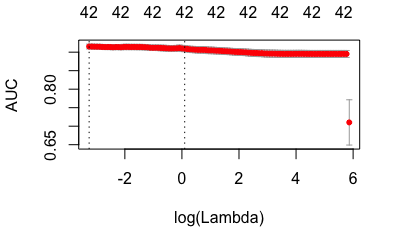

```r
plot(cv.ridge)
```

```r
#Con el valor mínimo de Lambda obtenemos los siguientes coeficientes
coef(cv.ridge, s=cv.ridge$lambda.min)
```

```
43 x 1 sparse Matrix of class "dgCMatrix"
                        1
(Intercept) -2.485132e+00
V1a          6.761196e-02
V1b         -6.730883e-02
V2           1.050470e-03
V3           2.039002e-02
V4l          1.866268e+00
V4u          1.120385e-01
V4y         -1.483951e-01
V5g          1.117918e-01
V5gg         1.864435e+00
V5p         -1.475257e-01
V6aa        -2.477690e-01
V6c         -1.256148e-02
V6cc         7.646021e-01
V6d         -3.253395e-01
V6e          3.816015e-01
V6ff        -6.911871e-01
V6i         -4.273618e-01
V6j         -1.394348e-01
V6k         -5.577796e-01
V6m         -1.108473e-02
V6q          1.220509e-01
V6r         -7.174644e-01
V6w          2.827815e-01
V6x          1.071131e+00
V7bb        -2.156105e-01
V7dd         2.386244e-01
V7ff        -5.445130e-01
V7h          3.861051e-01
V7j         -2.826013e-01
V7n          2.306995e+00
V7o         -6.560862e-01
V7v          1.184927e-02
V7z         -1.033052e+00
V8           5.328094e-02
V9t          2.329433e+00
V10t         7.506999e-01
V11          7.833016e-02
V12t        -1.175171e-01
V13p         1.654713e+00
V13s        -1.965547e-01
V14          2.294031e-05
V15          6.177723e-05
```

```r
coef(cv.ridge, s=cv.ridge$lambda.1se)
```

```
43 x 1 sparse Matrix of class "dgCMatrix"
                        1
(Intercept) -7.142332e-01
V1a          2.231218e-02
V1b         -2.231180e-02
V2           4.207324e-04
V3           1.033094e-02
V4l          3.387285e-01
V4u          7.600210e-02
V4y         -8.314273e-02
V5g          7.599098e-02
V5gg         3.387220e-01
V5p         -8.313270e-02
V6aa        -4.036278e-02
V6c         -2.792767e-03
V6cc         1.855253e-01
V6d         -1.312245e-01
V6e          4.982025e-02
V6ff        -1.951160e-01
V6i         -1.459135e-01
V6j         -8.554532e-02
V6k         -1.305202e-01
V6m          8.924822e-04
V6q          1.205389e-01
V6r          8.407382e-02
V6w          5.443982e-02
V6x          2.368457e-01
V7bb        -4.023901e-02
V7dd        -7.257985e-03
V7ff        -1.840554e-01
V7h          1.383479e-01
V7j         -1.002771e-01
V7n          1.517050e-01
V7o         -3.617301e-02
V7v         -2.036677e-02
V7z          2.227616e-02
V8           2.249010e-02
V9t          4.509883e-01
V10t         2.609431e-01
V11          2.041852e-02
V12t         2.025625e-02
V13p         6.828661e-02
V13s        -1.217295e-01
V14          2.225907e-04
V15          8.849909e-06
```

```r
y_pred_ridge <- as.numeric(predict.glmnet(cv.ridge$glmnet.fit, newx=x_test, s=cv.ridge$lambda.1se)>.5)
```

```r
confusionMatrix(factor(y_test), factor(y_pred_ridge), mode="everything")
```

```
Confusion Matrix and Statistics

          Reference
Prediction  0  1
         0 86  0
         1 11  3

               Accuracy : 0.89
                 95% CI : (0.8117, 0.9438)
    No Information Rate : 0.97
    P-Value [Acc > NIR] : 0.999952

                  Kappa : 0.3193
 Mcnemar's Test P-Value : 0.002569

            Sensitivity : 0.8866
            Specificity : 1.0000
         Pos Pred Value : 1.0000
         Neg Pred Value : 0.2143
              Precision : 1.0000
                 Recall : 0.8866
                     F1 : 0.9399
             Prevalence : 0.9700
         Detection Rate : 0.8600
   Detection Prevalence : 0.8600
      Balanced Accuracy : 0.9433

       'Positive' Class : 0
```

#### MODELO LASSO

Realizamos el entretamiento con regresion penalizada LASSO Alpha = 1. Buscamos el mejor Lambda. Utilizamos binomial al estar prediciendo una variable que toma dos posibles valores.

```r
set.seed(456)
cv.lasso <- cv.glmnet(x, y, alpha=1, family='binomial',parallel=TRUE, standardize=TRUE, type.measure='auc')
```

```
executing %dopar% sequentially: no parallel backend registered
```

```r
cv.lasso$lambda.min
```

```
[1] 0.00279411
```

```r
min(cv.lasso$cvm)
```

```
[1] 0.6244571
```

```r
max(cv.lasso$cvm)
```

```
[1] 0.921288
```

```r
#error estandar
cv.lasso$lambda.1se
```

```
[1] 0.02374305
```

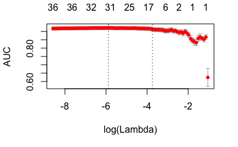

```r
plot(cv.lasso)
```

```r
cv.lasso$lambda.min
```

```
[1] 0.00279411
```

```r
max(cv.lasso$cvm)
```

```
[1] 0.921288
```

```r
coef(cv.lasso, s=cv.lasso$lambda.min)
```

```
43 x 1 sparse Matrix of class "dgCMatrix"
                        1
(Intercept) -3.085871e+00
V1a          7.700872e-02
V1b         -4.389144e-14
V2           3.264167e-04
V3           7.532990e-03
V4l          3.959544e+00
V4u          .
V4y         -5.961236e-01
V5g          .
V5gg         .
V5p         -8.163307e-05
V6aa        -2.241517e-01
V6c          .
V6cc         1.030255e+00
V6d         -1.035077e-01
V6e          8.482244e-01
V6ff        -1.214617e+00
V6i         -2.724380e-01
V6j          .
V6k         -5.653592e-01
V6m          .
V6q          .
V6r         -2.323066e+00
V6w          4.115943e-01
V6x          1.638499e+00
V7bb        -4.333879e-01
V7dd         .
V7ff         .
V7h          3.717855e-01
V7j         -1.685957e-01
V7n          4.248684e+00
V7o          .
V7v          .
V7z         -2.096993e+00
V8           5.314376e-02
V9t          3.408731e+00
V10t         7.115516e-01
V11          1.106462e-01
V12t        -1.881391e-01
V13p         2.762470e+00
V13s        -5.855650e-02
V14         -3.918199e-04
V15          2.981905e-04
```

```r
y_pred_lasso <- as.numeric(predict.glmnet(cv.lasso$glmnet.fit, newx=x_test, s=cv.lasso$lambda.min)>.5)
confusionMatrix(factor(y_test), factor(y_pred_lasso), mode="everything")
```

```
Confusion Matrix and Statistics

          Reference
Prediction  0  1
         0 84  2
         1  7  7

               Accuracy : 0.91
                 95% CI : (0.836, 0.958)
    No Information Rate : 0.91
    P-Value [Acc > NIR] : 0.5875

                  Kappa : 0.5605
 Mcnemar's Test P-Value : 0.1824

            Sensitivity : 0.9231
            Specificity : 0.7778
         Pos Pred Value : 0.9767
         Neg Pred Value : 0.5000
              Precision : 0.9767
                 Recall : 0.9231
                     F1 : 0.9492
             Prevalence : 0.9100
         Detection Rate : 0.8400
   Detection Prevalence : 0.8600
      Balanced Accuracy : 0.8504

       'Positive' Class : 0
```

Comparamos los AUC. Cuando se utiliza el meassure type AUC, en la variable CVM se guarda el AUC. Ver: https://es.wikipedia.org/wiki/Curva_ROC y http://rstudio-pubs-static.s3.amazonaws.com/42730_fc23dc874d5f4d08ac476b959e21250d.html

```r
AUC_ridge <- cv.ridge$cvm[cv.ridge$lambda == cv.ridge$lambda.min]
AUC_ridge
```

```
[1] 0.9152355
```

```r
AUC_lasso <- cv.lasso$cvm[cv.lasso$lambda == cv.lasso$lambda.min]
AUC_lasso
```

```
[1] 0.921288
```

#### Conclusiones

> Tras entrenar sendos modelos de regresión utilizando LASSO y RIDGE, seleccionamos aquel que tiene mejor AUC. En este caso el modelo obtenido mediante LASSO. Cuanto más “hacia arriba y hacia la izquierda” es curva ROC de un modelo, podemos decir que el modelos es mejor. La métrica de rendimiento de las AUC es, literalmente, el “Área debajo de la curva ROC”, por lo que cuanto mayor sea el área bajo esta curva, mayor será la AUC y el modelo con mejor rendimiento.

## Apartado 5

##### Aporta los log odds de las variables predictoras sobre la variable objetivo.

```r
exp(coef(cv.lasso, s=cv.lasso$lambda.min))
```

```
43 x 1 Matrix of class "dgeMatrix"
                      1
(Intercept)  0.04569022
V1a          1.08005150
V1b          1.00000000
V2           1.00032647
V3           1.00756143
V4l         52.43342483
V4u          1.00000000
V4y          0.55094317
V5g          1.00000000
V5gg         1.00000000
V5p          0.99991837
V6aa         0.79919389
V6c          1.00000000
V6cc         2.80178077
V6d          0.90166906
V6e          2.33549636
V6ff         0.29682364
V6i          0.76152064
V6j          1.00000000
V6k          0.56815603
V6m          1.00000000
V6q          1.00000000
V6r          0.09797273
V6w          1.50922208
V6x          5.14743632
V7bb         0.64830898
V7dd         1.00000000
V7ff         1.00000000
V7h          1.45032189
V7j          0.84485037
V7n         70.01319449
V7o          1.00000000
V7v          1.00000000
V7z          0.12282523
V8           1.05458125
V9t         30.22686482
V10t         2.03714968
V11          1.11699961
V12t         0.82849943
V13p        15.83892167
V13s         0.94312496
V14          0.99960826
V15          1.00029823
```

#### Conclusiones

> Vemos que se confirman algunas de las apreciaciones que hicimos en el primer apartado. La influencia de V9, de V6=x…

## Apartado 6

##### Si por cada verdadero positivo ganamos 100e y por cada falso positivo perdemos 20e. ¿ Qué rentabilidad aporta aplicar este modelo?

```r
matrix<-confusionMatrix(factor(y_test), factor(y_pred_lasso), mode="everything")
matrix
```

```
Confusion Matrix and Statistics

          Reference
Prediction  0  1
         0 84  2
         1  7  7

               Accuracy : 0.91
                 95% CI : (0.836, 0.958)
    No Information Rate : 0.91
    P-Value [Acc > NIR] : 0.5875

                  Kappa : 0.5605
 Mcnemar's Test P-Value : 0.1824

            Sensitivity : 0.9231
            Specificity : 0.7778
         Pos Pred Value : 0.9767
         Neg Pred Value : 0.5000
              Precision : 0.9767
                 Recall : 0.9231
                     F1 : 0.9492
             Prevalence : 0.9100
         Detection Rate : 0.8400
   Detection Prevalence : 0.8600
      Balanced Accuracy : 0.8504

       'Positive' Class : 0
```

Nos interesa minimizar los falsos positivos al penalizarse con 20. Entonces, si nos fijamos en la variable “precision” vemos que alcanzamos un valor de 0.9767.

```r
#calculo de la rentabilidad.
porcentage_ganancias<-as.double(matrix$byClass["Precision"]*100)
porcentage_perdidas<-100-ganancias
balance<-(porcentage_ganancias*100)-(porcentage_perdidas*20)
rentabilidad<-balance/100
rentabilidad
```

[output not shown]